# Lab2 Style Transfer

```python
import pandas as pd
names = ['Zhenxuan Ouyang','Jianmin Li', 'Xibai Li']
smuid = [47784546, 47794972, 48090995]
teaminfo = pd.DataFrame()
teaminfo['name'] = names
teaminfo['smu id'] = smuid
teaminfo
```

|  | name | smu id |
| --- | --- | --- |
| 0 | Zhenxuan Ouyang | 47784546 |
| 1 | Jianmin Li | 47794972 |
| 2 | Xibai Li | 48090995 |

```python
import tensorflow
print(tensorflow.__version__)
import keras
print(keras.__version__)
```

```
2.1.0
2.3.1
```

## [10 Points] Manipulate the above VGG code to use un-pooling layers as in the Photo Realistic Li et al. paper. Alternatively, you can use strided convolutions without any pooling steps if you want. You can also use another network besides VGG (such as UNET).

The code below is for training, no need to run this time.

```python
import tensorflow as tf
from pathlib import PurePath
import numpy as np
from PIL import Image
from matplotlib import pyplot as plt
from keras.preprocessing import image
import imageio
import cv2

class VGG19AE(tf.keras.Model):
    '''
    Pre-trained decode, thanks to Yihao's model:
    https://github.smu.edu/48066464/CS8321Lab2_Decoder
    '''
    def __init__(self, files_path):
        super(VGG19AE, self).__init__()
        #Load Model
        ModelBlock5 = tf.keras.models.load_model(str(PurePath(files_path, 'Block5_Model')), compile = False)
        #Get Each SubModel
        self.E5 = ModelBlock5.layers[0]
        self.D5 = ModelBlock5.layers[1]
        self.O5 = ModelBlock5.layers[2]
        ModelBlock4 = tf.keras.models.load_model(str(PurePath(files_path, 'Block4_Model')), compile = False)
        self.E4 = ModelBlock4.layers[0]
        self.D4 = ModelBlock4.layers[1]
        self.O4 = ModelBlock4.layers[2]
        ModelBlock3 = tf.keras.models.load_model(str(PurePath(files_path, 'Block3_Model')), compile = False)
        self.E3 = ModelBlock3.layers[0]
        self.D3 = ModelBlock3.layers[1]
        self.O3 = ModelBlock3.layers[2]
        ModelBlock2 = tf.keras.models.load_model(str(PurePath(files_path, 'Block2_Model')), compile = False)
        self.E2 = ModelBlock2.layers[0]
        self.D2 = ModelBlock2.layers[1]
        self.O2 = ModelBlock2.layers[2]
        ModelBlock1 = tf.keras.models.load_model(str(PurePath(files_path, 'Block1_Model')), compile = False)
        self.E1 = ModelBlock1.layers[0]
        self.O1 = ModelBlock1.layers[1]

        ######### MAKR 1: ##########
#         for layer in ModelBlock4.layers:
#             print(layer.get_config())
#             thelayer = layer.get_config().get('layers')
#             if thelayer is not None:
#                 for item in thelayer:
#                     print(item.get('class_name'))

    def wct(self, content, style, alpha=0.6, eps=1e-5):
        '''
        https://github.com/eridgd/WCT-TF/blob/master/ops.py

           Perform Whiten-Color Transform on feature maps using numpy
           See p.4 of the Universal Style Transfer paper for equations:
           https://arxiv.org/pdf/1705.08086.pdf
        '''
        # 1xHxWxC -> CxHxW
        content_t = np.transpose(np.squeeze(content), (2, 0, 1))
        style_t = np.transpose(np.squeeze(style), (2, 0, 1))

        # CxHxW -> CxH*W
        content_flat = content_t.reshape(-1, content_t.shape[1] * content_t.shape[2])
        style_flat = style_t.reshape(-1, style_t.shape[1] * style_t.shape[2])

        # Whitening transform
        mc = content_flat.mean(axis=1, keepdims=True)
        fc = content_flat - mc
        fcfc = np.dot(fc, fc.T) / (content_t.shape[1] * content_t.shape[2] - 1)
        Ec, wc, _ = np.linalg.svd(fcfc)
        k_c = (wc > 1e-5).sum()
        Dc = np.diag((wc[:k_c] + eps) ** -0.5)
        fc_hat = Ec[:, :k_c].dot(Dc).dot(Ec[:, :k_c].T).dot(fc)

        # Coloring transform
        ms = style_flat.mean(axis=1, keepdims=True)
        fs = style_flat - ms
        fsfs = np.dot(fs, fs.T) / (style_t.shape[1] * style_t.shape[2] - 1)
        Es, ws, _ = np.linalg.svd(fsfs)
        k_s = (ws > 1e-5).sum()
        Ds = np.sqrt(np.diag(ws[:k_s] + eps))
        fcs_hat = Es[:, :k_s].dot(Ds).dot(Es[:, :k_s].T).dot(fc_hat)
        fcs_hat = fcs_hat + ms

        # Blend transform features with original features
        blended = alpha * fcs_hat + (1 - alpha) * (fc)

        # CxH*W -> CxHxW
        blended = blended.reshape(content_t.shape)
        # CxHxW -> 1xHxWxC
        blended = np.expand_dims(np.transpose(blended, (1, 2, 0)), 0)

        return np.float32(blended)

    def call(self, Image, training=False, select_model=4, styling=False, alpha=0.6):

        if select_model==4:
            xo, I2 = Image
            x = self.E4(xo)
            style = self.E4(I2)
            if styling==True:
                #Add WCT
                x = self.wct(content=x, style=style, alpha=alpha, eps=1e-5)
            x = self.D4(x)
            x = self.O4(x)
        elif select_model==3:
            xo, I2 = Image
            x = self.E3(xo)
            style = self.E3(I2)
            if styling==True:
                #Add WCT
                x = self.wct(content=x, style=style, alpha=alpha, eps=1e-5)
            x = self.D3(x)
            x = self.O3(x)
        elif select_model==2:
            xo, I2 = Image
            x = self.E2(xo)
            style = self.E2(I2)
            if styling==True:
                #Add WCT
                x = self.wct(content=x, style=style, alpha=alpha, eps=1e-5)
            x = self.D2(x)
            x = self.O2(x)

        # Block 1 Do not have decoder because it don't contain Pooling and there are only one Conv layer.
        x = self.E1(x)
        x = self.O1(x)
        # return tf.squeeze(x)
        return tf.clip_by_value(tf.squeeze(x), 0, 1)
```

We did some research about what are inside of Yihao's model (in the "MARK 1" code above), and found out he is using Conv2DTranspose with 2 strides instead of unpooling.

## [10 Points] Show a few images and their reconstructions using each decoder. Comment on any artifacts from the images.

```python
def get_reconstruction_img(input_img_path, select_model):
    AE = VGG19AE('Model')

    input_img = tf.keras.preprocessing.image.load_img(input_img_path)
    input_img = tf.keras.preprocessing.image.img_to_array(input_img)
    input_img = cv2.resize(input_img, (384, 384))

    # This style image isn't used in this pure reconstructioin process
    STYLE_INPUT_PATH = './style6-384x384.jpg'
    input_style = tf.keras.preprocessing.image.load_img(STYLE_INPUT_PATH)
    input_style = tf.keras.preprocessing.image.img_to_array(input_style)
    input_style = cv2.resize(input_style, (384, 384))

    input_img = input_img / 255
    input_style = input_style / 255

    # Make it 4D Tensor
    Image_sample_input = (tf.expand_dims(input_img, 0), tf.expand_dims(input_style, 0))

    # When styling is False, the model will only do the reconstruction without styling.
    Out_image = AE(Image_sample_input, select_model=select_model, styling=False)

    return Out_image

def display_reconstruction_img(original_img_path, select_model):
    input_img = tf.keras.preprocessing.image.load_img(original_img_path)
    input_img = tf.keras.preprocessing.image.img_to_array(input_img)
    input_img = cv2.resize(input_img, (384, 384))
    input_img = input_img / 255

    Out_image = get_reconstruction_img(original_img_path, select_model)

    plt.figure(figsize=(15,15))
    plt.subplot(1, 2, 1)
    plt.title("ModelBlock"+str(select_model)+" original image")
    plt.imshow(np.clip(input_img, 0, 1))
    plt.subplot(1, 2, 2)
    plt.title("ModelBlock"+str(select_model)+" reconstruction image")
    plt.imshow(Out_image)
    plt.show()
    # imageio.imwrite('./output.jpg', Out_image)
    tf.keras.preprocessing.image.save_img('./output.jpg', Out_image)
```

### ModelBlock4 reconstruction result

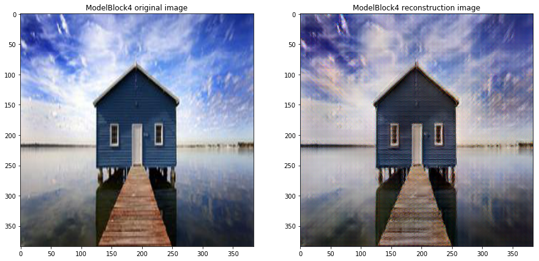

```python
INPUT_IMG_PATH = './data/landscape_dataset/70.jpg'
display_reconstruction_img(INPUT_IMG_PATH, select_model=4)
```

The reconstruction result of ModelBlock4 is not too bad. It still looks normal, but almost all pixels have a little bit of distortion which make color slightly different. Besides, the distortion of house's edge and its shadow is much more server than other part.

### ModelBlock2 reconstruction result

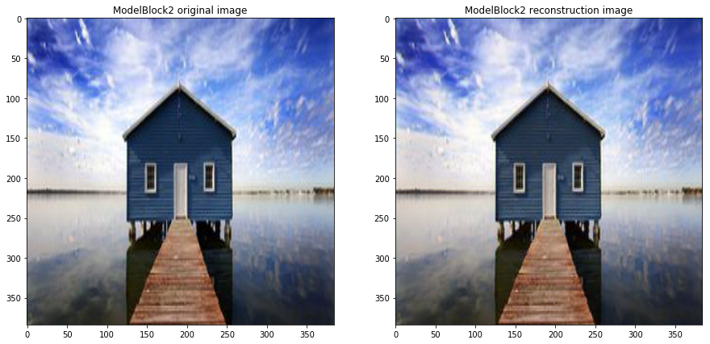

```python
INPUT_IMG_PATH = './data/landscape_dataset/70.jpg'
display_reconstruction_img(INPUT_IMG_PATH, select_model=2)
```

ModelBlock2 is doing better than ModelBlock4, whose output image is much more close to the original one.

## [10 Points] Implement the whitening and coloring transform as described by Li et al. An implementation of this has already been written for you, available in the link above. Show a few images that are style transferred using this method. You may use an SVD decomposition or an Eigen Decomposition, depending on the precision of your machine and desired stability.

We first need to do some modification of the process of creating this model. According to Universal Style Transfer via Feature Transforms by Li etc.

```python
class VGG19AE2(tf.keras.Model):
    '''
    Pre-trained decode, thanks to Yihao's model:
    https://github.smu.edu/48066464/CS8321Lab2_Decoder
    '''
    def __init__(self, files_path):
        super(VGG19AE2, self).__init__()
        #Load Model
        ModelBlock5 = tf.keras.models.load_model(str(PurePath(files_path, 'Block5_Model')), compile = False)
        #Get Each SubModel
        self.E5 = ModelBlock5.layers[0]
        self.D5 = ModelBlock5.layers[1]
        self.O5 = ModelBlock5.layers[2]
        ModelBlock4 = tf.keras.models.load_model(str(PurePath(files_path, 'Block4_Model')), compile = False)
        self.E4 = ModelBlock4.layers[0]
        self.D4 = ModelBlock4.layers[1]
        self.O4 = ModelBlock4.layers[2]
        ModelBlock3 = tf.keras.models.load_model(str(PurePath(files_path, 'Block3_Model')), compile = False)
        self.E3 = ModelBlock3.layers[0]
        self.D3 = ModelBlock3.layers[1]
        self.O3 = ModelBlock3.layers[2]
        ModelBlock2 = tf.keras.models.load_model(str(PurePath(files_path, 'Block2_Model')), compile = False)
        self.E2 = ModelBlock2.layers[0]
        self.D2 = ModelBlock2.layers[1]
        self.O2 = ModelBlock2.layers[2]
        ModelBlock1 = tf.keras.models.load_model(str(PurePath(files_path, 'Block1_Model')), compile = False)
        self.E1 = ModelBlock1.layers[0]
        self.O1 = ModelBlock1.layers[1]

        ######### MAKR 1: ##########
#         for layer in ModelBlock4.layers:
#             print(layer.get_config())
#             thelayer = layer.get_config().get('layers')
#             if thelayer is not None:
#                 for item in thelayer:
#                     print(item.get('class_name'))

    def wct(self, content, style, alpha=0.6, eps=1e-5):
        '''
        https://github.com/eridgd/WCT-TF/blob/master/ops.py

           Perform Whiten-Color Transform on feature maps using numpy
           See p.4 of the Universal Style Transfer paper for equations:
           https://arxiv.org/pdf/1705.08086.pdf
        '''
        # 1xHxWxC -> CxHxW
        content_t = np.transpose(np.squeeze(content), (2, 0, 1))
        style_t = np.transpose(np.squeeze(style), (2, 0, 1))

        # CxHxW -> CxH*W
        content_flat = content_t.reshape(-1, content_t.shape[1] * content_t.shape[2])
        style_flat = style_t.reshape(-1, style_t.shape[1] * style_t.shape[2])

        # Whitening transform
        mc = content_flat.mean(axis=1, keepdims=True)
        fc = content_flat - mc
        fcfc = np.dot(fc, fc.T) / (content_t.shape[1] * content_t.shape[2] - 1)
        Ec, wc, _ = np.linalg.svd(fcfc)
        k_c = (wc > 1e-5).sum()
        Dc = np.diag((wc[:k_c] + eps) ** -0.5)
        fc_hat = Ec[:, :k_c].dot(Dc).dot(Ec[:, :k_c].T).dot(fc)

        # Coloring transform
        ms = style_flat.mean(axis=1, keepdims=True)
        fs = style_flat - ms
        fsfs = np.dot(fs, fs.T) / (style_t.shape[1] * style_t.shape[2] - 1)
        Es, ws, _ = np.linalg.svd(fsfs)
        k_s = (ws > 1e-5).sum()
        Ds = np.sqrt(np.diag(ws[:k_s] + eps))
        fcs_hat = Es[:, :k_s].dot(Ds).dot(Es[:, :k_s].T).dot(fc_hat)
        fcs_hat = fcs_hat + ms

        # Blend transform features with original features
        blended = alpha * fcs_hat + (1 - alpha) * (fc)

        # CxH*W -> CxHxW
        blended = blended.reshape(content_t.shape)
        # CxHxW -> 1xHxWxC
        blended = np.expand_dims(np.transpose(blended, (1, 2, 0)), 0)

        return np.float32(blended)

    def call(self, Image, training = False, select_model=4, styling=True, alpha=0.8):
        # print("inside call")
        # Input should be 4D Tensor
        xo, I2 = Image
        x = self.E2(xo)
        style = self.E2(I2)
        # Add WCT
        x = self.wct(content=x, style=style, alpha=alpha, eps=1e-5)
        x = self.D2(x)
        x = self.O2(x)

#         x = self.E3(x)
#         style = self.E3(I2)
#         x = self.wct(content=x, style=style, alpha=alpha, eps=1e-5)
#         x = self.D3(x)
#         x = self.O3(x)

#         x = self.E2(x)
#         style = self.E2(I2)
#         x = self.wct(content=x, style=style, alpha=alpha, eps=1e-5)
#         x = self.D2(x)
#         x = self.O2(x)


        # Block 1 Do not have decoder because it don't contain Pooling and there are only one Conv layer.
        x = self.E1(x)
        x = self.O1(x)
        # return tf.squeeze(x)
        return tf.clip_by_value(tf.squeeze(x), 0, 1)
```

```python
def get_stylized_img(input_img, input_style):
    AE2 = VGG19AE2('Model')

    # Make it 4D Tensor
    Image_sample_input = (tf.expand_dims(input_img, 0), tf.expand_dims(input_style, 0))

    Out_image = AE2(Image_sample_input, styling=True, alpha=0.8)
    return Out_image

def display_stylized_img(content_img_path, style_img_path, savedname):
    input_img = tf.keras.preprocessing.image.load_img(content_img_path)
    input_img = tf.keras.preprocessing.image.img_to_array(input_img)
    input_img = cv2.resize(input_img, (384, 384))
    input_img = input_img / 255

    input_style = tf.keras.preprocessing.image.load_img(style_img_path)
    input_style = tf.keras.preprocessing.image.img_to_array(input_style)
    input_style = cv2.resize(input_style, (384, 384))
    input_style = input_style / 255

    Out_image = get_stylized_img(input_img, input_style)
    plt.figure(figsize=(20,20))
    plt.subplot(1, 3, 1)
    plt.title("Content image")
    plt.imshow(np.clip(input_img, 0, 1))
    plt.subplot(1, 3, 2)
    plt.title("Style image")
    plt.imshow(np.clip(input_style, 0, 1))
    plt.subplot(1, 3, 3)
    plt.title("Stylized image")
    plt.imshow(Out_image)
    plt.show()
#     cv2.imwrite('./output/'+savedname+'.jpg', Out_image)
    imageio.imsave('./output/'+savedname+'.jpg', Out_image)
```

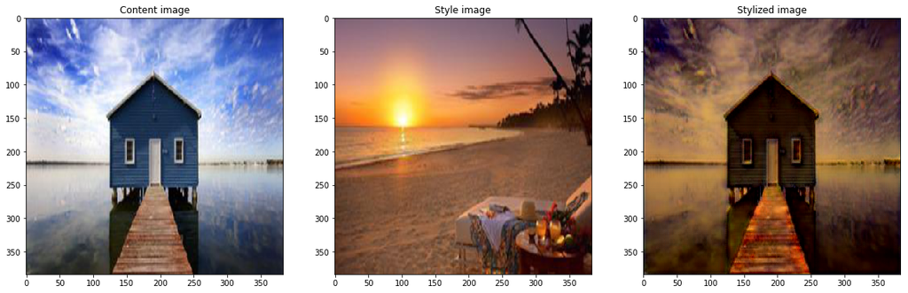

```
Lossy conversion from float32 to uint8. Range [0, 1]. Convert image to uint8 prior to saving to suppress this warning.
```

```python
INPUT_IMG_PATH = './data/landscape_dataset/70.jpg'
STYLE_INPUT_PATH = './data/landscape_dataset/62.jpg'
display_stylized_img(INPUT_IMG_PATH, STYLE_INPUT_PATH, 'stylized-70')
```

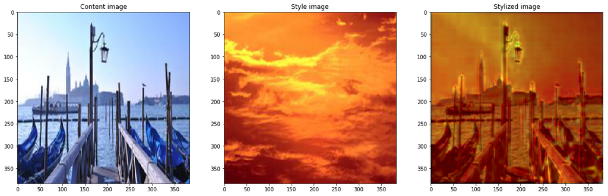

```
Lossy conversion from float32 to uint8. Range [0, 1]. Convert image to uint8 prior to saving to suppress this warning.
```

```python
INPUT_IMG_PATH = './data/landscape_dataset/3554.jpg'
STYLE_INPUT_PATH = './data/landscape_dataset/3593.jpg'
display_stylized_img(INPUT_IMG_PATH, STYLE_INPUT_PATH, 'stylized-3554')
```

## [10 Points] Exceptional work: Implement the smoothing constraint from Li et al. to achieve more photo realistic style transfer results. Show a few photo style changes from the network. If using code from another author (not your own), you will be graded on the clarity of explanatory comments you add to the code.

We use some existing code for the smoothing constraint from here: https://github.com/NVIDIA/FastPhotoStyle/blob/master/photo_smooth.py

We tried to understand the code, but it's really hard. And we also made some comments based on our understanding and some papers.

```python
"""
Copyright (C) 2018 NVIDIA Corporation.    All rights reserved.
Licensed under the CC BY-NC-SA 4.0 license (https://creativecommons.org/licenses/by-nc-sa/4.0/legalcode).
"""
from __future__ import division
# import torch.nn as nn
import scipy.misc
import numpy as np
import scipy.sparse
import scipy.sparse.linalg
from numpy.lib.stride_tricks import as_strided
from PIL import Image


class Propagator():
    def __init__(self, beta=0.9999):
        super(Propagator, self).__init__()
        self.beta = beta

    def process(self, initImg, contentImg):


        # read content image
        if type(contentImg) == str:
            content = imageio.imread(contentImg)
        else:
            content = contentImg.copy()

        # read stylized image Y
        if type(initImg) == str:
            Y = imageio.imread(initImg).astype(np.float64) / 255
        else:
            Y = scipy.asarray(initImg).astype(np.float64) / 255

        h1,w1,k = Y.shape
        h = h1 - 4
        w = w1 - 4

        # resize Y and content to the same size
        Y = Y[int((h1-h)/2):int((h1-h)/2+h),int((w1-w)/2):int((w1-w)/2+w),:]
        content = cv2.resize(content,(h,w))

        # edge padding
        Y = self.__replication_padding(Y,2)
        content = self.__replication_padding(content,2)
        content = content.astype(np.float64)/255
        Y = np.reshape(Y,(h1*w1,k))

        # compute W, which size is (B.pixel, B.pixel)
        W = self.__compute_laplacian(content)
        # Compressed Sparse Column format
        W = W.tocsc()

        # Dii
        dd = W.sum(0)

        # S = D^(-1/2)WD^(-1/2)
        dd = np.sqrt(np.power(dd,-1))
        dd = dd.A.squeeze()
        D = scipy.sparse.csc_matrix((dd, (np.arange(0,w1*h1), np.arange(0,w1*h1)))) # 0.026
        S = D.dot(W).dot(D)

        # A = I - alpha*D^(-1/2)WD^(-1/2)
        A = scipy.sparse.identity(w1*h1) - self.beta*S
        A = A.tocsc()

        # V = (I - alpha*D^(-1/2)WD^(-1/2))^(-1)Y
        solver = scipy.sparse.linalg.factorized(A)
        V = np.zeros((h1*w1,k))
        V[:,0] = solver(Y[:,0])
        V[:,1] = solver(Y[:,1])
        V[:,2] = solver(Y[:,2])

        # R_hat = (1-alpha)(I - alpha*D^(-1/2)WD^(-1/2))^(-1)Y
        R_hat = V*(1-self.beta)
        R_hat = R_hat.reshape(h1,w1,k)
        R_hat = R_hat[2:2+h,2:2+w,:]

        img = Image.fromarray(np.uint8(np.clip(R_hat * 255., 0, 255.)))
        return img

    # Returns sparse matting laplacian
    # The implementation of the function is heavily borrowed from
    # https://github.com/MarcoForte/closed-form-matting/blob/master/closed_form_matting.py
    # We thank Marco Forte for sharing his code.
    def __compute_laplacian(self, img, eps=10**(-7), win_rad=1):

        # window size
        win_size = (win_rad*2+1)**2

        # height, width, channel
        h, w, d = img.shape

        # height and width of rolling window matrix
        c_h, c_w = h - 2*win_rad, w - 2*win_rad

        # window diameter
        win_diam = win_rad*2+1

        # (h, w) index matrix
        indsM = np.arange(h*w).reshape((h, w))

        # reshape img (h,w,d) to (h*w,d)
        ravelImg = img.reshape(h*w, d)

        # rolling window index matrix
        win_inds = self.__rolling_block(indsM, block=(win_diam, win_diam))

        # reshape to (img_height-2, img_width-2, window_size)
        win_inds = win_inds.reshape(c_h, c_w, win_size)

        # window Image matrix, shape = (h, w, win_size, d)
        winI = ravelImg[win_inds]

        # mean in each window
        win_mu = np.mean(winI, axis=2, keepdims=True)

        # variance in each window
        win_var = np.einsum('...ji,...jk ->...ik', winI, winI)/win_size - np.einsum('...ji,...jk ->...ik', win_mu, win_mu)

        # inverse of window variance plus (eps/win_size)*I3
        inv = np.linalg.inv(win_var + (eps/win_size)*np.eye(3))

        # (winI - win_mu) dot win_var^(-1) in the last 2 dimension
        X = np.einsum('...ij,...jk->...ik', winI - win_mu, inv)

        # vals = (1/win_size)*(1+(I-win_mu)*(win_var + eps/win_size*I3)^(-1)(I-win_mu))
        # which is in paper "A Closed Form Solution to Natural Image Matting" formula (12)
        # https://webee.technion.ac.il/people/anat.levin/papers/Matting-Levin-Lischinski-Weiss-CVPR06.pdf
        vals = (1/win_size)*(1 + np.einsum('...ij,...kj->...ik', X, winI - win_mu))

        # save as sparse matrix
        nz_indsCol = np.tile(win_inds, win_size).ravel()
        nz_indsRow = np.repeat(win_inds, win_size).ravel()
        nz_indsVal = vals.ravel()
        L = scipy.sparse.coo_matrix((nz_indsVal, (nz_indsRow, nz_indsCol)), shape=(h*w, h*w))
        return L

    def __replication_padding(self, arr,pad):
        # padding pad size of the same value as it adjacent on the edge of each channel of the picture
        # assume arr.shape is (x,y,z), ans.shape is (x+2*pad, y+2*pad, z), padding with the same value
        # on the edge of arr
        h,w,c = arr.shape
        ans = np.zeros((h+pad*2,w+pad*2,c))
        for i in range(c):
                ans[:,:,i] = np.pad(arr[:,:,i],pad_width=(pad,pad),mode='edge')
        return ans

    def __rolling_block(self, A, block=(3, 3)):
        # return a 4d array which has all the slide windows on A with size block
        # for example, assume A is np.arange(25).reshape(5,5) and block is (3, 3)
        # the answer is [[[[ 0  1  2]
        #                  [ 5  6  7]
        #                  [10 11 12]]

        #                 [[ 1  2  3]
        #                  [ 6  7  8]
        #                  [11 12 13]]

        #                 [[ 2  3  4]
        #                  [ 7  8  9]
        #                  [12 13 14]]]            #end of first row

        #                 ...]
        shape = (A.shape[0] - block[0] + 1, A.shape[1] - block[1] + 1) + block
        strides = (A.strides[0], A.strides[1]) + A.strides
        return as_strided(A, shape=shape, strides=strides)
```

Test for some matrix computation are at below, which are already explained in comment.

```python
# pad test
a = np.arange(25).reshape(5,5)
print(np.pad(a,pad_width=(2,2),mode='edge'))

# rolling test
a = np.arange(25).reshape(5,5)
print(as_strided(a, shape=(a.shape[0]-2, a.shape[1]-2)+(3,3), strides=((a.strides[0], a.strides[1]) + a.strides)))

# test for mean in dimension 2
a = np.arange(125).reshape(5,5,5)
print(np.mean(a, axis=2, keepdims=True))

# test for einsum, mutiply last 2 dimension as ij*kj->ik
a = np.arange(625).reshape(5,5,5,5)
b = np.ones(625).reshape(5,5,5,5)
print(np.einsum('...ij,...kj ->...ik', a, b))

# test for einsum, mutiply last 2 dimension as ij*jk->ik
a = np.arange(25).reshape(5,5)
b = np.arange(25).reshape(5,5)
np.einsum('...ij,...jk->...ik', a, b)
```

```
[[ 0  0  0  1  2  3  4  4  4]
 [ 0  0  0  1  2  3  4  4  4]
 [ 0  0  0  1  2  3  4  4  4]
 [ 5  5  5  6  7  8  9  9  9]
 [10 10 10 11 12 13 14 14 14]
 [15 15 15 16 17 18 19 19 19]
 [20 20 20 21 22 23 24 24 24]
 [20 20 20 21 22 23 24 24 24]
 [20 20 20 21 22 23 24 24 24]]
[[[[ 0  1  2]
   [ 5  6  7]
   [10 11 12]]

  [[ 1  2  3]
   [ 6  7  8]
   [11 12 13]]

  [[ 2  3  4]
   [ 7  8  9]
   [12 13 14]]]


 [[[ 5  6  7]
   [10 11 12]
   [15 16 17]]

  [[ 6  7  8]
   [11 12 13]
   [16 17 18]]

  [[ 7  8  9]
   [12 13 14]
   [17 18 19]]]


 [[[10 11 12]
   [15 16 17]
   [20 21 22]]

  [[11 12 13]
```

[output cut: 173 more lines]

```
   [2810. 2810. 2810. 2810. 2810.]
   [2835. 2835. 2835. 2835. 2835.]
   [2860. 2860. 2860. 2860. 2860.]]

  [[2885. 2885. 2885. 2885. 2885.]
   [2910. 2910. 2910. 2910. 2910.]
   [2935. 2935. 2935. 2935. 2935.]
   [2960. 2960. 2960. 2960. 2960.]
   [2985. 2985. 2985. 2985. 2985.]]

  [[3010. 3010. 3010. 3010. 3010.]
   [3035. 3035. 3035. 3035. 3035.]
   [3060. 3060. 3060. 3060. 3060.]
   [3085. 3085. 3085. 3085. 3085.]
   [3110. 3110. 3110. 3110. 3110.]]]]
```

```
array([[ 150,  160,  170,  180,  190],
       [ 400,  435,  470,  505,  540],
       [ 650,  710,  770,  830,  890],
       [ 900,  985, 1070, 1155, 1240],
       [1150, 1260, 1370, 1480, 1590]])
```

```python
def display_smooth_result(initImg_path, contentImg_path):
    propagator = Propagator()
    smooth_img = propagator.process(INIT_IMG_PATH, CONTENT_IMG_PATH)

    plt.figure(figsize=(15,15))
    plt.subplot(1,2,1)
    plt.title('stylized image Before Smoothing')
    plt.imshow(imageio.imread(initImg_path))

    plt.subplot(1,2,2)
    plt.title('stylized image After Smoothing')
    plt.imshow(smooth_img)

    plt.show()
```

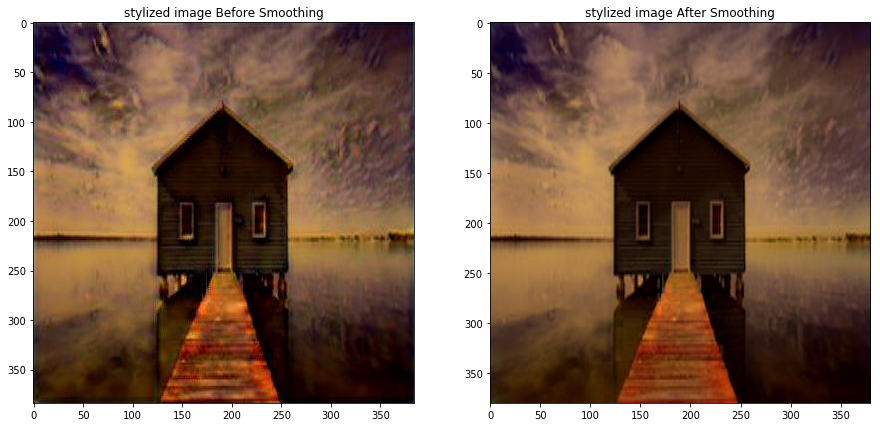

```python
INIT_IMG_PATH = './output/stylized-70.jpg'
CONTENT_IMG_PATH = './data/landscape_dataset/70.jpg'
display_smooth_result(INIT_IMG_PATH, CONTENT_IMG_PATH)
```

The bridge looks more naturally after smoothing.

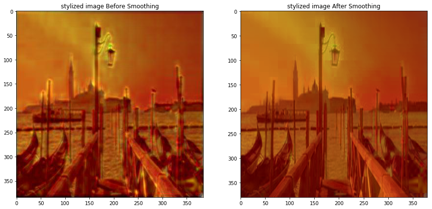

```python
INIT_IMG_PATH = './output/stylized-3554.jpg'
CONTENT_IMG_PATH = './data/landscape_dataset/3554.jpg'
display_smooth_result(INIT_IMG_PATH, CONTENT_IMG_PATH)
```